# Linear models

Download linear_20221122.Rmd Download linear_20221122.R Download shagLPI.csv Download Weevil_damage.csv

```r
library(Hmisc)
library(corrplot)
library(MASS)
library(car)
library(interactions)
library(yarrr)
library(tidyr)
library(readr)
library(lme4)
library (lmerTest)
library(nlme)
library(gvlma)
library(simpleboot)
library(DAAG)
library(bootstrap)
library(MBESS)
library(leaps)
```

In the coming two weeks, we will take some time on basic concepts behind some simple linear models.

# Linear regression

## Definition

Let’s start with a a simple correlation among two variables:

```r
# correlation
rairuoho<-read.table('D:/R_WD/Git linked/2022RisFUN-Mo/Statistics/Data-statistic/rairuoho.txt',header=T, sep="\t", dec=".")
cor.test(rairuoho$day6, rairuoho$day7)
```

```
##
##  Pearson's product-moment correlation
##
## data:  rairuoho$day6 and rairuoho$day7
## t = 9.562, df = 46, p-value = 1.658e-12
## alternative hypothesis: true correlation is not equal to 0
## 95 percent confidence interval:
##  0.6918585 0.8928613
## sample estimates:
##       cor
## 0.8156516
```

We can repeat it for all days by building a Pearson coefficient matrix:

```r
corr<-cor(rairuoho[,1:6])
corr # cor.test does not work on Matrix
```

```
##           day3      day4      day5      day6      day7      day8
## day3 1.0000000 0.7669682 0.5994600 0.5464308 0.3558050 0.2255945
## day4 0.7669682 1.0000000 0.7692091 0.7943134 0.6027304 0.4544520
## day5 0.5994600 0.7692091 1.0000000 0.7524457 0.5541184 0.4053586
## day6 0.5464308 0.7943134 0.7524457 1.0000000 0.8156516 0.6754468
## day7 0.3558050 0.6027304 0.5541184 0.8156516 1.0000000 0.8398937
## day8 0.2255945 0.4544520 0.4053586 0.6754468 0.8398937 1.0000000
```

Which however doesn’t give us the p-values of those correlations. Many packages offer a better visualization of this matrix, such as `corrplot`:

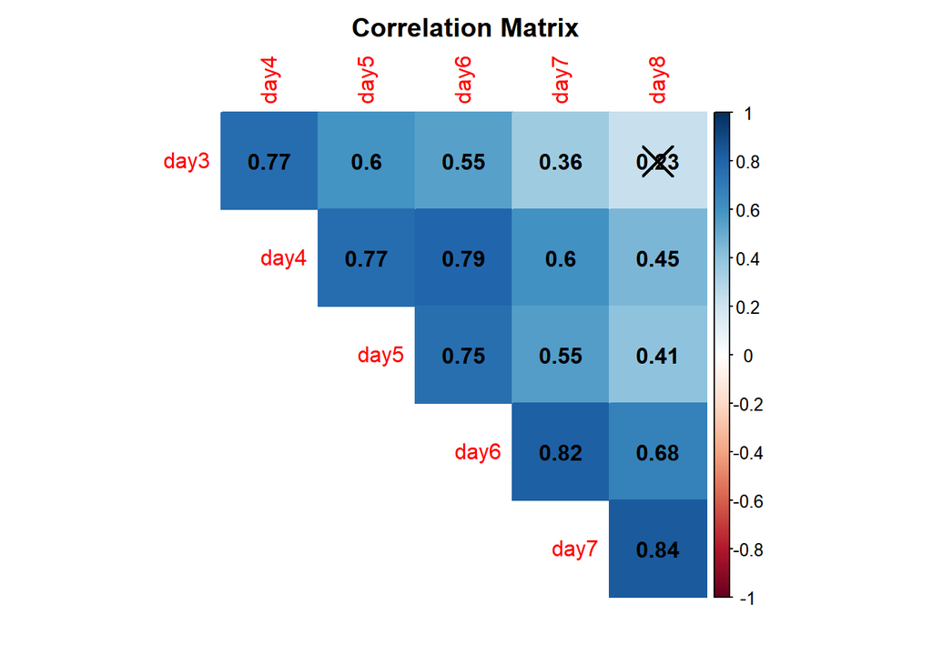

```r
p.val<-rcorr(as.matrix(rairuoho[,1:6]))$P
corrplot(corr,type='upper',method='color', addCoef.col = "black", p.mat=as.matrix(p.val), sig.level = 0.05,title = "Correlation Matrix", mar = c(2,0,2,0), diag=F)
```

Previously, we saw that this type of ‘relationship’ (a linear model `lm`) between two variables can be added to a scatterplot using the function `abline`

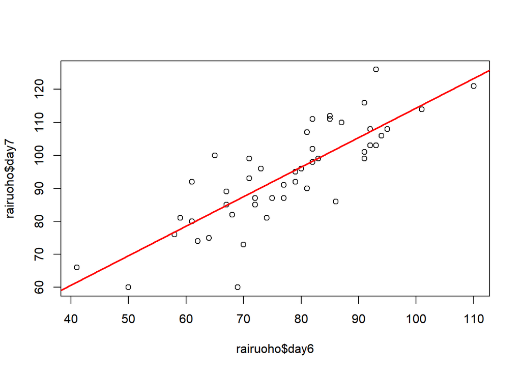

```r
plot(rairuoho$day6, rairuoho$day7)
abline(lm(rairuoho$day7~rairuoho$day6), col="red", lwd=2)
```

```r
# remember `ggplot`
# ggplot(rairuoho, aes(x = day6, y = day7)) +
#  geom_point() +
#  stat_smooth(method = "lm", col = "red")
```

Indeed our correlation derived from a simple **linear regression**. In **Model I regression** (indeed we have Model II when two variable in the regression equation are random , i.e. no controlled by the researcher), it is used to predict a quantitative outcome of a dependent variable $y$ on the basis of one single independent predictor variable $x$. The goal is to build a mathematical model (or formula) that defines $y$ as a function of the $x$ variable.

Once, we built a statistically significant model, it’s possible to use it for predicting future outcome on the basis of new $x$ values.

## Formula and basics

The formula of linear regression can be written as follows:
$$y = \beta_0 + \beta_1*x + \epsilon$$

where:

- $\beta_0$ and $\beta_1$ are known as the regression **beta coefficients** or **parameters**:
  - $\beta_0$ is the **intercept** of the regression line; that is the predicted value when *x = 0*.
  - $\beta1$ is the **slope** of the regression line.
- $\epsilon$ is the **error term** (also known as the **residual errors**)

The figure below illustrates the linear regression model, where:

- the best-fit regression line is in blue
- the intercept ($\beta_0$) and the slope ($\beta_1$) are shown in green
- the error terms ($\epsilon$) are represented by vertical red lines

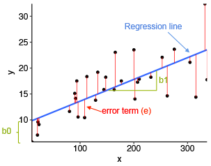

From the figure above, it can be seen that not all the data points fall exactly on the fitted regression line. Some of the points are above the blue curve and some are below it; overall, the residual errors ($\epsilon$) have approximately mean zero.

**TERMINOLOGY ALERT**

The sum of the squares of the residual errors are called the **Residual Sum of Squares** or **RSS**.

The average variation of points around the fitted regression line is called the **Residual Standard Error (RSE)**. This is one the metrics used to evaluate the overall quality of the fitted regression model. The lower the RSE, the better it is.

Since the mean error term is zero, the outcome variable y can be approximately estimated as follow:

$$y= \beta_0+\beta_1*x$$

Mathematically, the beta coefficients ($\beta_0$ and $\beta_1$) are determined so that the **RSS** is as minimal as possible. This method of determining the beta coefficients is technically called **least squares** regression or **ordinary least squares** (OLS) regression.

Once, the beta coefficients are calculated, a *t*-test is performed to check whether or not these coefficients are significantly different from zero. A non-zero beta coefficients means that there is a significant relationship between the predictors ($x$) and the outcome variable ($y$).

## Computation

Finally! The simple linear regression tries to find the best line to predict $y$ on the basis of $x$.

In the `iris` data set, a linear model equation can be written as follow:

$Petal.Width = \beta_0 + \beta_1 * Petal.Length$

In R language, it is translated using the function `lm` and in order to determine the beta coefficients of the linear model:

```r
model1 <- lm(Petal.Width ~ Petal.Length, data = iris)
model1$coefficients
```

```
##  (Intercept) Petal.Length
##   -0.3630755    0.4157554
```

The results show the intercept ($\beta_0$) and the slope ($\beta_1$), i.e. the beta coefficients for the `Petal.Length` variable

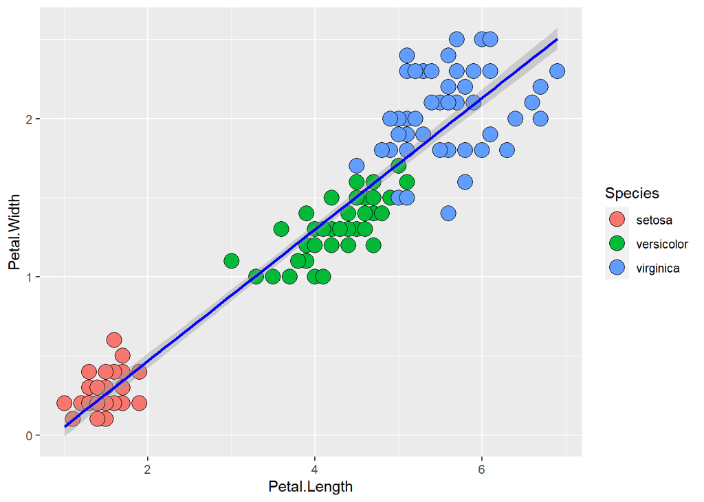

```r
ggplot(iris, aes(x = Petal.Length, y = Petal.Width)) +
  geom_point(aes(fill=Species),shape = 21, size=5) +
  stat_smooth(method = "lm", col = "blue")
```

## Interpretation

From the output above:

- the estimated regression line equation can be written as follow: $Petal.Width = -0.3631 + 0.4158*Petal.Length$
- the intercept ($\beta_0$) is $-0.3631$. It can be interpreted as the predicted width of petal for a length of petal equal to zero. Regression through the origin is when you force the intercept of a regression model to equal zero. It’s also known as fitting a model without an intercept (e.g., the intercept-free linear model $y = \beta_1*x$ is equivalent to the model $y = \beta_0 + \beta_1*x$ with $\beta_0=0$). Knowing that the **true relationship** between your predictors and the expected value of your dependent variable has to pass through the origin would be a good reason for forcing the estimated relationship through the origin if you knew for certain what the true relationship was (be careful very rare cases where it is justified to remove the intercept).
- the regression beta coefficient for the variable `Petal.Length` ($\beta1$), also known as the slope, is $0.4158$. This means that, for one unit of $Petal.Length$, we can expect an increase of $0.4158$ units in $Petal.Width$.

## Model assessment

Before using our model to predict $Petal.Width$, we should make sure that this model is statistically significant, that is:

- there is a statistically significant relationship between the predictor and the outcome variables
- the model that we built fits very well the data in our hand.

## Model summary

Using our `lm` model, we get a bit more than just the coefficient ($\beta0$) and ($\beta1$)

```r
summary(model1)
```

```
##
## Call:
## lm(formula = Petal.Width ~ Petal.Length, data = iris)
##
## Residuals:
##      Min       1Q   Median       3Q      Max
## -0.56515 -0.12358 -0.01898  0.13288  0.64272
##
## Coefficients:
##               Estimate Std. Error t value Pr(>|t|)
## (Intercept)  -0.363076   0.039762  -9.131  4.7e-16 ***
## Petal.Length  0.415755   0.009582  43.387  < 2e-16 ***
## ---
## Signif. codes:  0 '***' 0.001 '**' 0.01 '*' 0.05 '.' 0.1 ' ' 1
##
## Residual standard error: 0.2065 on 148 degrees of freedom
## Multiple R-squared:  0.9271, Adjusted R-squared:  0.9266
## F-statistic:  1882 on 1 and 148 DF,  p-value: < 2.2e-16
```

Looking at only the p-values, this simple model seems to fit the data very well. But the output tells us much more. The summary outputs shows 6 components, including:

- **Call** shows the function call used to compute the regression model.
- **Residuals** provide a quick view of the distribution of the residuals, which by definition have a mean zero. Therefore, the median should not be far from zero, and the minimum and maximum should be roughly equal in absolute value.
- **Coefficients** shows the regression beta coefficients and their statistical significance. Predictor variables, that are significantly associated to the outcome variable, are marked by stars.
- **Residual standard error** (RSE), **R-squared** (R2) and the **F-statistic** are metrics that are used to check how well the model fits to our data.

### Coefficients significance

The coefficients table, in the model statistical summary, shows:

- the estimates of the **beta coefficients**
- the **standard errors** (SE), which defines the accuracy of beta coefficients. For a given beta coefficient, the SE reflects how the coefficient varies under repeated sampling. It can be used to compute the confidence intervals and the t-statistic.
- the *t*-statistic and the associated *p*-value, which defines the statistical significance of the beta coefficients.

**t-statistic and p-values**

For a given predictor, the t-statistic (and its associated *p*-value) tests whether or not there is a statistically significant relationship between a given predictor and the outcome variable, that is whether or not the beta coefficient of the predictor is significantly different from zero.

The statistical hypotheses are as follow:

- Null hypothesis (H<sub>0</sub>): the coefficients are equal to zero (i.e., no relationship between x and y)
- Alternative Hypothesis (H<sub>1</sub>): the coefficients are not equal to zero (i.e., there is some relationship between $x$ and $y$)

Mathematically, for a given beta coefficient ($\beta$), the *t*-test is computed as $t = (\beta - 0)/SE(\beta)$, where $SE(\beta)$ is the SE of the coefficient $\beta$. Simply said, the t-statistic measures the number of standard deviations that $\beta$ is away from 0. Thus a large *t*-statistic will produce a small p-value (=different).

The higher the *t*-statistic (and the lower the p-value), the more significant the predictor. The symbols to the right (***) visually specifies the level of significance. The line below the table shows the definition of these symbols; one star means 0.01 < p < 0.05. The more the stars beside the variable’s p-value, the more significant the variable.

A statistically significant coefficient indicates that there is an association between the predictor ($x$) and the outcome ($y$) variable.

The *t*-statistic is a very useful guide for whether or not to include a predictor in a model. High t-statistics (which go with low p-values near 0) indicate that a predictor should be retained in a model, while very low *t*-statistics indicate a predictor could be dropped (Bruce and Bruce 2017).

**Standard errors and confidence intervals**

The standard error measures the variability/accuracy of the beta coefficients. It can be used to compute the confidence intervals of the coefficients.

For example, the 95% confidence interval for the coefficient $\beta1$ is defined as $\beta1 +/- 2*SE(\beta1)$, where:

the lower limits of $\beta_1 = \beta_1 - 2*SE(\beta_1) = 0.415 - 2*0.009 = 0.397$

the upper limits of $\beta1 = \beta1 + 2*SE(\beta1) = 0.415 + 2*0.009 = 0.435$

That is, there is approximately a 95% chance that the interval [0.397, 0.435] will contain the true value of $\beta1$. Similarly the 95% confidence interval for $\beta0$ can be computed as $\beta0 +/- 2*SE(\beta0)$.

To get this information, either you calculate by hands or you simply call:

```r
confint(model1)
```

```
##                   2.5 %     97.5 %
## (Intercept)  -0.4416501 -0.2845010
## Petal.Length  0.3968193  0.4346915
```

### Model accuracy

Once you identified that, at least, one predictor variable is significantly associated the outcome, you should continue the diagnostic by checking how well the model fits the data. This process is also referred to as the *goodness-of-fit*

The overall quality of the linear regression fit can be assessed using the following three parameters, displayed in the model summary:

1. **The Residual Standard Error (RSE)**

The **RSE** (also known as the model sigma) is the **residual variation**, representing the average variation of the observations points around the fitted regression line. This is the **standard deviation of residual errors**.

RSE provides an absolute measure of patterns in the **data that can’t be explained by the model**. When comparing two models, the model with the small RSE is a good indication that this model fits the best the data.

Dividing the RSE by the average value of the outcome variable will give you the prediction error rate, which should be as small as possible.

In our example, RSE = `0.2065`, meaning that the observed Petal.width values deviate from the true regression line by approximately `0.2065` units in average.

Whether or not an RSE of `0.2065` units is an acceptable prediction error is subjective and depends on the problem context. However, we can calculate the percentage error. In our data set, the mean value of Petal.Width is 1.1993, and so the percentage error is 0.2065/1.1993 = 17%.

```r
sigma(model1)*100/mean(iris$Petal.Width)
```

```
## [1] 17.21659
```

2. **The R-squared ($R^2$)**

The **R-squared** $R^2$ ranges from 0 to 1 and represents the **proportion of information (i.e. variation) in the data that can be explained by the model**. The **adjusted $R^2$ adjusts $R^2$ with the degrees of freedom**.

The $R^2$ measures, how well the model fits the data. For a simple linear regression, $R^2$ is the square of the **Pearson correlation coefficient**.

A high value of $R^2$ is a good indication. However, as the value of $R^2$ tends to increase when more predictors are added in the model, such as in **multiple linear regression mode**l, you should mainly consider the adjusted $R^2$**, which is a penalized $R^2$ for a higher number of predictors.

- An (adjusted) $R^2$ that is close to 1 indicates that a large proportion of the variability in the outcome has been explained by the regression model.
- A number near 0 indicates that the regression model did not explain much of the variability in the outcome.
3. **F-statistic**

The **F-statistic** gives the overall significance of the model. It assess whether **at least one predictor variable has a non-zero coefficient**.

In a simple linear regression, this test is not really interesting since it just duplicates the information in given by the *t*-test, available in the coefficient table. In fact, the *F*-test is identical to the square of the t-test: $1882 = (43.387)^2$. That would be true in any model with 1 degree of freedom.

The F-statistic becomes **more important** once we start **using multiple predictors** as in multiple linear regression.

A large F-statistic will corresponds to a statistically significant *p*-value (p < 0.05). In our example, the F-statistic equal 1882 producing a p-value of < 2.2e-16, which is highly significant.

# Multiple regression

**Multiple linear regression** is just an **extension of simple linear regression** used to predict an outcome variable ($y$) on the basis of multiple distinct predictor variables ($x$).

With three predictor variables ($x$), the prediction of $y$ is expressed by the following equation:

$$y = \beta_0 + \beta_1*x_1 + \beta_2*x_2
+ \beta_3*x_3$$

The “$\beta$” values are called the regression weights (or beta coefficients). They measure the association between the predictor variable and the outcome. “$\beta_j$” can be interpreted as the average effect on $y$ of a one unit increase in “$x_j$”, holding all other predictors fixed.

## Fitting the model

R provides comprehensive support for multiple linear regression. We want to build a model for estimating `Petal.Width` based on data we get on `Petal.Length`, `Sepal.Length`, and `Sepal.Width`.

$$Petal.Width = \beta_0 +
\beta_1*Petal.Length + \beta_2*Sepal.Length +
\beta_3*Sepal.Width$$
You can now easily compute this in R as follow:

```r
fit1 <- lm(Petal.Width ~ Petal.Length + Sepal.Width + Sepal.Length, data = iris)
summary(fit1)
```

```
##
## Call:
## lm(formula = Petal.Width ~ Petal.Length + Sepal.Width + Sepal.Length,
##     data = iris)
##
## Residuals:
##      Min       1Q   Median       3Q      Max
## -0.60959 -0.10134 -0.01089  0.09825  0.60685
##
## Coefficients:
##              Estimate Std. Error t value Pr(>|t|)
## (Intercept)  -0.24031    0.17837  -1.347     0.18
## Petal.Length  0.52408    0.02449  21.399  < 2e-16 ***
## Sepal.Width   0.22283    0.04894   4.553 1.10e-05 ***
## Sepal.Length -0.20727    0.04751  -4.363 2.41e-05 ***
## ---
## Signif. codes:  0 '***' 0.001 '**' 0.01 '*' 0.05 '.' 0.1 ' ' 1
##
## Residual standard error: 0.192 on 146 degrees of freedom
## Multiple R-squared:  0.9379, Adjusted R-squared:  0.9366
## F-statistic: 734.4 on 3 and 146 DF,  p-value: < 2.2e-16
```

```r
# Other useful functions
coefficients(fit1) # model coefficients
confint(fit1, level=0.95) # CIs for model parameters
fitted(fit1) # predicted values
residuals(fit1) # residuals
anova(fit1) # anova table
vcov(fit1) # covariance matrix for model parameters
influence(fit1) # regression diagnostics
```

## Regression diagnostics

See [here](https://www.statmethods.net/stats/rdiagnostics.html) for functions and packages

### Diagnostic plots

[Diagnostic](http://strata.uga.edu/8370/rtips/regressionPlots.html) plots provide checks for heteroscedasticity, normality, and influential observations.

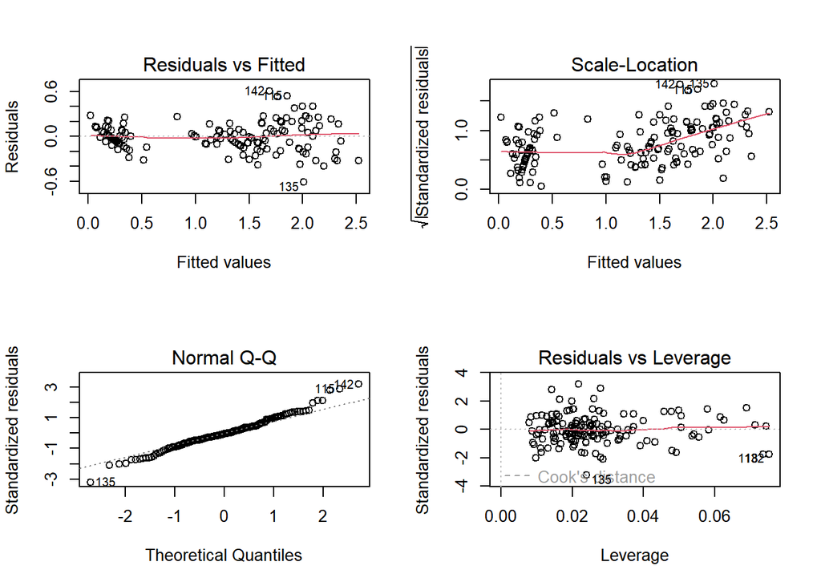

```r
# diagnostic plots
layout(matrix(c(1,2,3,4),2,2)) # optional 4 graphs/page
plot(fit1)
```

1. **Residuals vs. fitted** plot.

This plot serves mainly to check the linearity, although lack of homoscedasticity or independence can also be detected. Under linearity, we expect the red line (a nonlinear fit of the mean of the residuals) to be almost flat. This means that the trend of $Y_1,...,Y_n$ is linear with respect to the predictors. Heteroscedasticity can be detected also in the form of irregular vertical dispersion around the red line. The dependence between residuals can be detected (harder) in the form of non randomly spread residuals.

2. **Normal Q-Q** plot. Check the normality

Under normality, we expect the points (sample quantiles of the standardized residuals vs. theoretical quantiles of a $N(0,1)$ **to align with the diagonal line**, which represents the ideal position of the points if those were sampled from a $N(0,1)$. It is usual to have larger departures from the diagonal in the extremes than in the center, even under normality, although these departures are more clear if the data is non-normal.

3. **Scale-location** plot.

Serves for checking the **homoscedasticity**. It is similar to the first diagnostic plot, but now with the residuals standardized and transformed by a square root (of the absolute value). This change transforms the task of spotting heteroskedasticity by looking into irregular vertical dispersion patterns into spotting for nonlinearities, which is somehow simpler. **Under homoscedasticity, we expect the red line to be almost flat.** If there are consistent nonlinear patterns, then there is evidence of heteroscedasticity.

4. **Residuals versus Leverage** to detect outlier and check for the normality. On this plot, you want to see that the red smoothed line stays close to the horizontal gray dashed line and that no points have a large Cook’s distance (i.e, >0.5).

### Outliers

```r
# Assessing Outliers
outlierTest(fit1) # Bonferonni p-value for most extreme obs
```

```
## No Studentized residuals with Bonferroni p < 0.05
## Largest |rstudent|:
##      rstudent unadjusted p-value Bonferroni p
## 135 -3.323084          0.0011271      0.16907
```

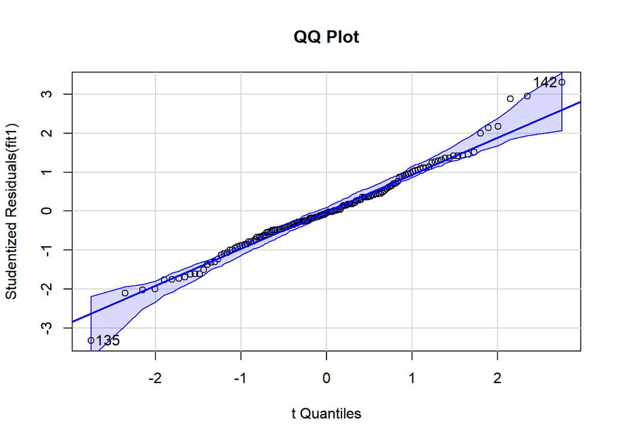

```
## [1] 135 142
```

```r
qqPlot(fit1, main="QQ Plot") #qq plot for studentized resid
```

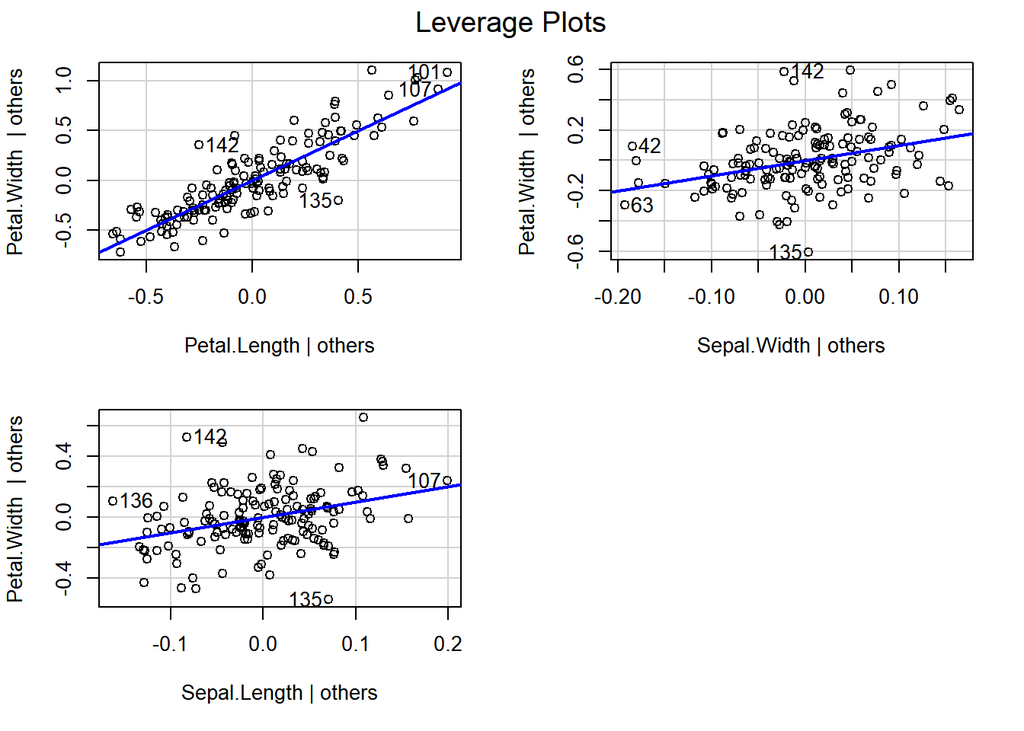

```r
leveragePlots(fit1) # leverage plots
```

### Influential observations

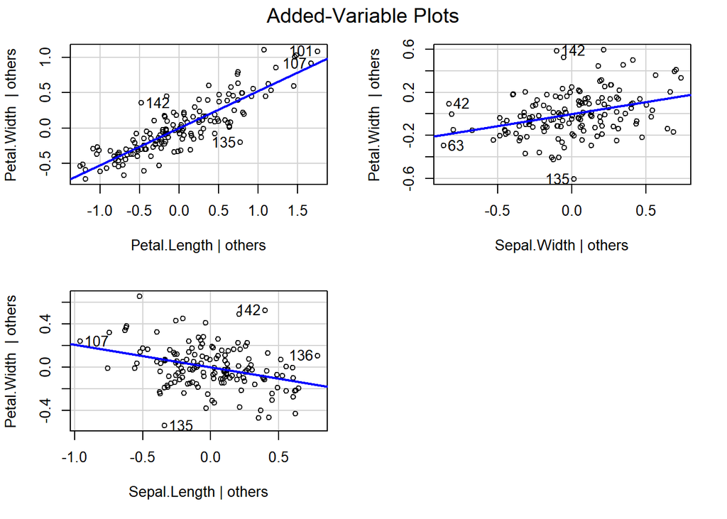

```r
# Influential Observations
# added variable plots
avPlots(fit1)
```

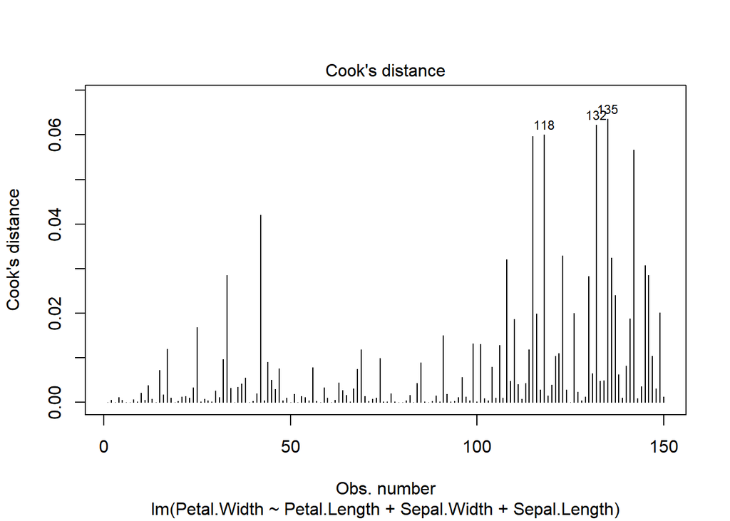

```r
# Cook's D plot
# identify D values > 4/(n-k-1)
cutoff <- 4/((nrow(iris)-length(fit1$coefficients)-2))
plot(fit1, which=4, cook.levels=cutoff)
```

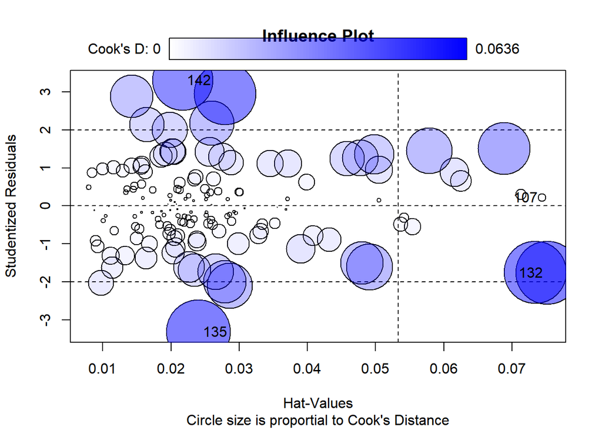

```
##       StudRes        Hat        CookD
## 107  0.218388 0.07440127 0.0009647108
## 132 -1.763159 0.07518199 0.0622805793
## 135 -3.323084 0.02404521 0.0636400285
## 142  3.302796 0.02171837 0.0566956801
```

```r
# Influence Plot
influencePlot(fit1, id.method="identify", main="Influence Plot", sub="Circle size is proportial to Cook's Distance" )
```

### Non-normality

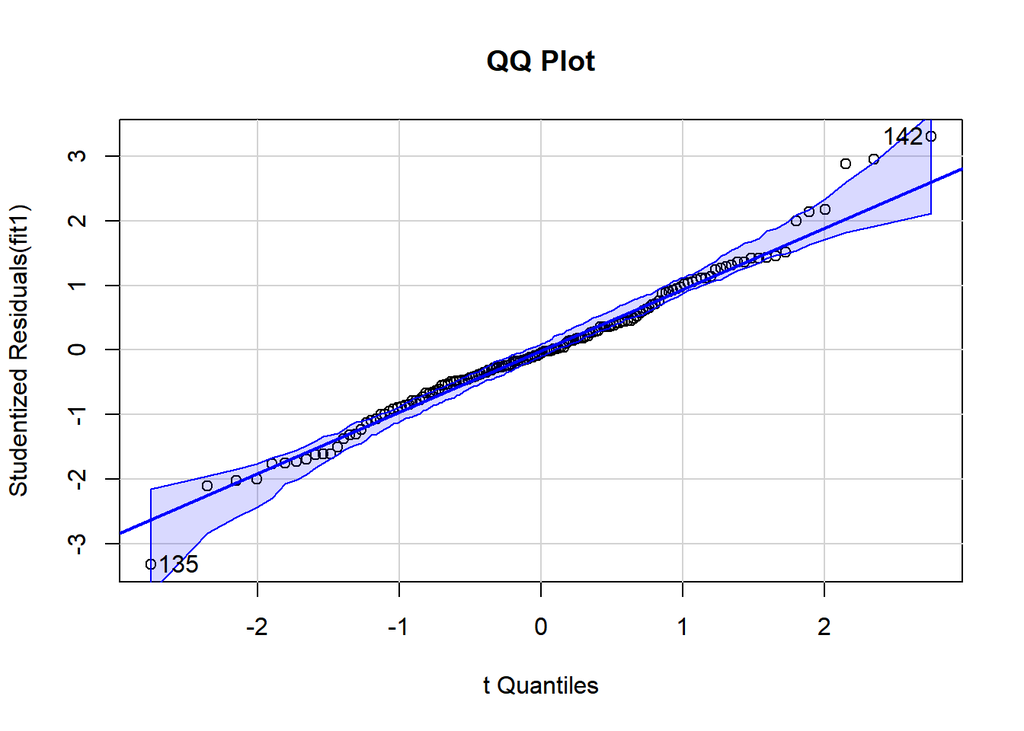

```
## [1] 135 142
```

```r
# Normality of Residuals
# qq plot for studentized resid
qqPlot(fit1, main="QQ Plot")
```

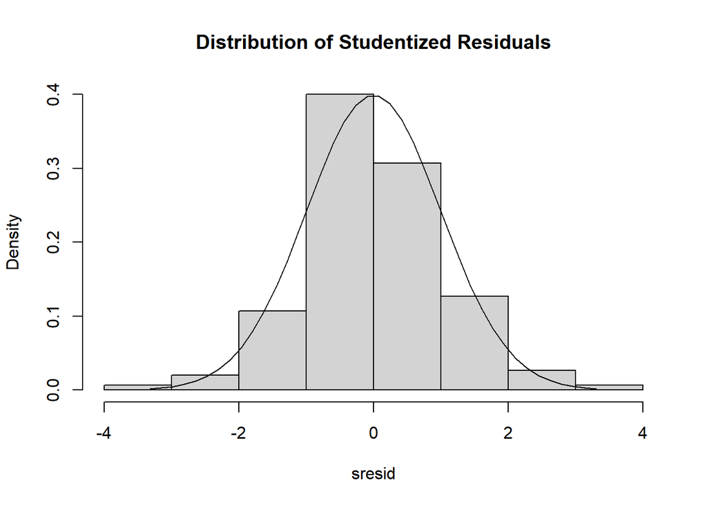

```r
# distribution of studentized residuals
sresid <- studres(fit1)
hist(sresid, freq=FALSE,
   main="Distribution of Studentized Residuals")
xfit<-seq(min(sresid),max(sresid),length=40)
yfit<-dnorm(xfit)
lines(xfit, yfit)
```

### Non-constant Error Variance

```r
# Evaluate homoscedasticity
# non-constant error variance test
ncvTest(fit1)
```

```
## Non-constant Variance Score Test
## Variance formula: ~ fitted.values
## Chisquare = 25.96744, Df = 1, p = 3.4722e-07
```

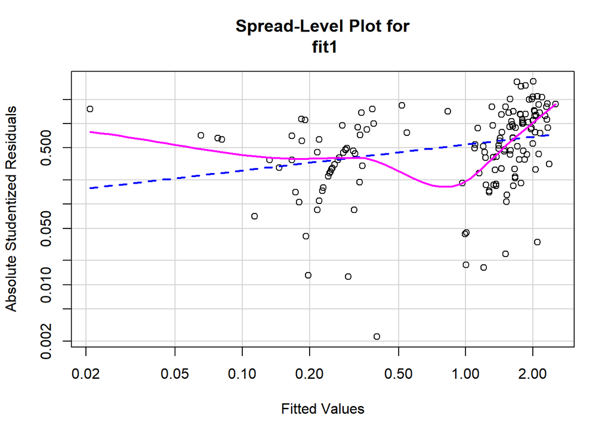

```
##
## Suggested power transformation:  0.6773452
```

```r
# plot studentized residuals vs. fitted values
spreadLevelPlot(fit1)
```

### Multi-collinearity

A common problem that arises in multiple linear regression is the **multi-collinearity**. This is the situation when two or more predictors are highly linearly related between them. Multicollinearitiy has important effects on the fit of the model:

- It reduces the precision of the estimates. As a consequence, signs of fitted coefficients may be reversed and valuable predictors may appear as non significant.
- It is difficult to determine how each of the highly related predictors affects the response, since one masks the other. This may result in numerical instabilities.

An approach is to detect multicollinearity is to compute a correlation matrix between the predictors as we learned earlier

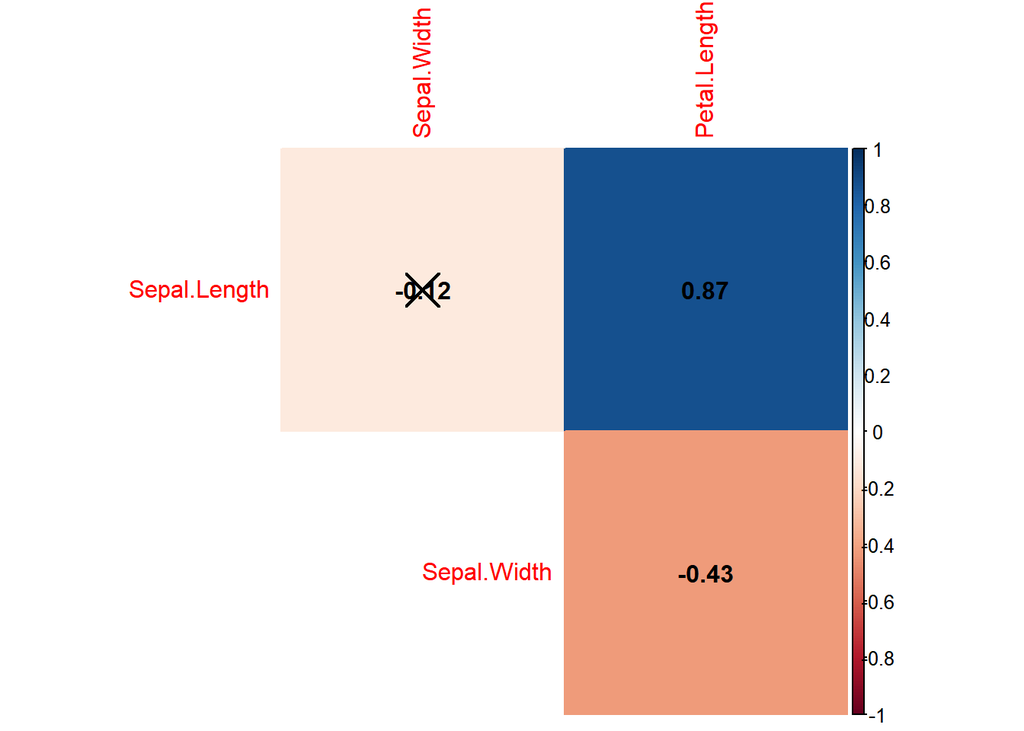

Here we can see what we already knew that `Sepal.Length` and `Petal.Length` are highly linearly related. One could be removed. However, it is not enough to inspect pair by pair correlations in order to get rid of multicollinearity.A better approach is to compute the **Variance Inflation Factor** (VIF) of each coefficient $\beta_j$. This is measure of how linearly dependent is $X_j$ with the rest of predictors:

$$\text{VIF}(\beta_j)=\frac{1}{1-R^2_{X_j|X_{-j}}}$$

where $R^2_{X_j|X_{-j}}$ is the $R^2$ from a regression of $X_j$ into the remaining predictors. The next rule of thumb gives direct insight into which predictors are multicollinear:

- **VIF close to 1**: absence of multicollinearity.
- **VIF larger than 5 or 10**: multicolinearity **problematic**.

Other considered $\sqrt{VIF}>2$ as critical limit to consider multicollinearity.

```r
# Evaluate Collinearity
car::vif(fit1) # variance inflation factors
```

```
## Petal.Length  Sepal.Width Sepal.Length
##     7.557780     1.839639     6.256954
```

```r
sqrt(car::vif(fit1)) > 2 # problem?
```

```
## Petal.Length  Sepal.Width Sepal.Length
##         TRUE        FALSE         TRUE
```

### Nonlinearity

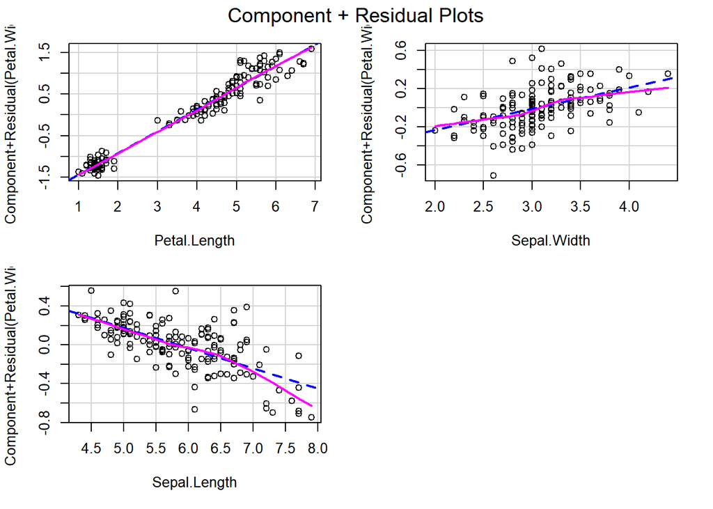

```r
# Evaluate Nonlinearity
# component + residual plot
crPlots(fit1)
```

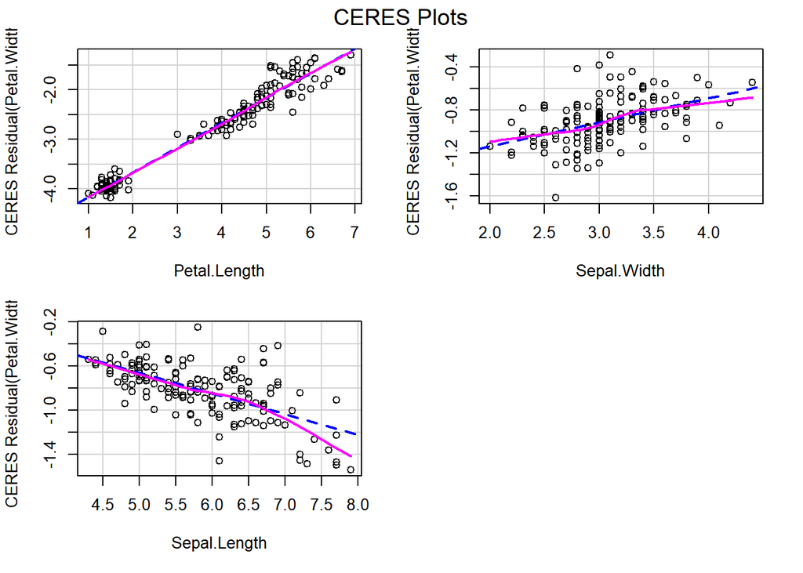

```r
# Ceres plots
ceresPlots(fit1)
```

### Non-independence of Errors

```r
# Test for Autocorrelated Errors
durbinWatsonTest(fit1)
```

```
##  lag Autocorrelation D-W Statistic p-value
##    1       0.2129038      1.573009   0.006
##  Alternative hypothesis: rho != 0
```

### Additional Diagnostic Help

Based on Pena and Slate (2006), the four assumptions in linear regression are normality, heteroscedasticity, and linearity, and what the authors refer to as uncorrelatedness.

The `gvlma( )` function in the `gvlma` package, performs a global validation of linear model assumptions as well separate evaluations of skewness, kurtosis, and heteroscedasticity.

```r
gvmodel <- gvlma(fit1)
summary(gvmodel)
```

```
##
## Call:
## lm(formula = Petal.Width ~ Petal.Length + Sepal.Width + Sepal.Length,
##     data = iris)
##
## Residuals:
##      Min       1Q   Median       3Q      Max
## -0.60959 -0.10134 -0.01089  0.09825  0.60685
##
## Coefficients:
##              Estimate Std. Error t value Pr(>|t|)
## (Intercept)  -0.24031    0.17837  -1.347     0.18
## Petal.Length  0.52408    0.02449  21.399  < 2e-16 ***
## Sepal.Width   0.22283    0.04894   4.553 1.10e-05 ***
## Sepal.Length -0.20727    0.04751  -4.363 2.41e-05 ***
## ---
## Signif. codes:  0 '***' 0.001 '**' 0.01 '*' 0.05 '.' 0.1 ' ' 1
##
## Residual standard error: 0.192 on 146 degrees of freedom
## Multiple R-squared:  0.9379, Adjusted R-squared:  0.9366
## F-statistic: 734.4 on 3 and 146 DF,  p-value: < 2.2e-16
##
##
## ASSESSMENT OF THE LINEAR MODEL ASSUMPTIONS
## USING THE GLOBAL TEST ON 4 DEGREES-OF-FREEDOM:
## Level of Significance =  0.05
##
## Call:
##  gvlma(x = fit1)
##
##                       Value   p-value                   Decision
## Global Stat        45.91070 2.571e-09 Assumptions NOT satisfied!
## Skewness            1.24561 2.644e-01    Assumptions acceptable.
## Kurtosis            5.56557 1.832e-02 Assumptions NOT satisfied!
## Link Function       0.03784 8.458e-01    Assumptions acceptable.
## Heteroscedasticity 39.06169 4.106e-10 Assumptions NOT satisfied!
```

This tests for the linear model assumptions and helpfully provides information on other assumptions. In this case we are going to look at the heteroskedasticity decisions, which has been identified as not being satisfied. We therefore reject the null hypothesis and state that there is heteroskedasticity in this model at the 5% significance level.

1. Global Stat This is the overall metric; this states whether the model, as a whole, passes or fails.
2. Skewness: measuring the distribution
3. Kurtosis: measuring the distribution, outliers, influential data, etc
4. Link function: misspecified model, how you linked the elements in the model assignment
5. Heteroscedasticity: looking for equal variance in the residuals

## Dealing with violation of assumption

A method of choice for addressing any violations of assumptions is often simple scale transformation of either the dependent or the independent variables, or both. The Box-Cox transformation is a power transformation that eliminates non-linearity between variables, differing variances, and variable asymmetry.The ability to turn a variable into a new variable with a normal distribution is therefore very helpful.

The following expression gives the Box-Cox functions transformations for various values of lambda:

$\frac{x^λ-1}λ$ if $λ\neq0$

$log(x)$ if $λ=0$

being y the changed variable and lambda (λ) the transformation parameter However, the following table describes the most typical transformations:

| λ | Transformation |
| --- | --- |
| -2 | $\frac{1}{x^2}$ |
| -1 | $\frac{1}{x}$ |
| -0.5 | $\frac{1}{\sqrt{x}}$ |
| 0 | $log(x)$ |
| 0.5 | $sqrt{x}$ |
| 1 | $x$ |
| 2 | $x^2$ |

In practice, it is advised to choose the value from the table rather than the precise value if the estimated transformation parameter is close to one of the values of the previous table because the value from the table is simpler to understand. Below is a quick implementation of Box-Cox transformation capabilities is introduced. In this instance, the goal is to find an exponent to use to transform the dependant variavel to help produce normality and homoscedasticity of the residuals. The peak of the curve in the plot yields λ, the scaling component.

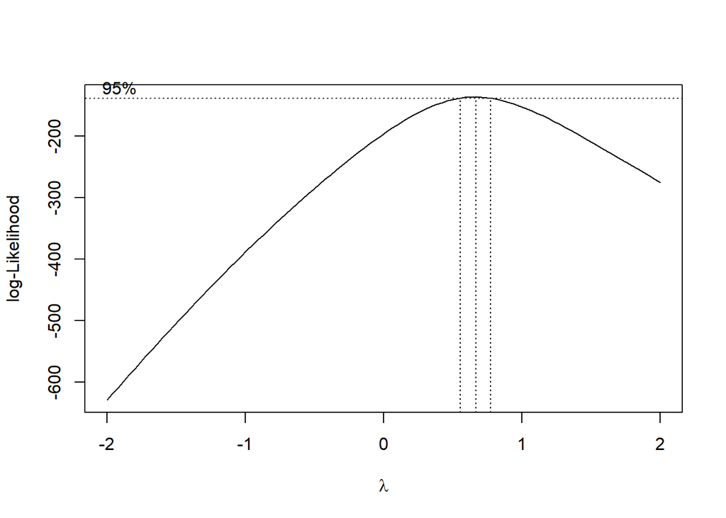

```r
boxcoxfit <- boxcox(fit1,plotit=T)
```

```r
# also see `boxCox` from **car**
# also see `BoxCoxTrans` from **caret** for individual variable
```

Find the optimal λ for Box-Cox transformation

```r
lambda <- boxcoxfit$x[which.max(boxcoxfit$y)]
```

For this model, λ is was found to be about 0.667 (approximately equivalent to a square root transformation). This value would be used to transform the dependent variable and to rerun the previous analysis. But recall that the normality was not big deal earlier but the heteroscedasticity was at the opposite a big issue.

```r
#fit new linear regression model using the Box-Cox transformation
new_fit <- lm(((iris$Petal.Width^lambda-1)/lambda) ~ Petal.Length + Sepal.Width + Sepal.Length, data = iris)
```

```r
gvlma(new_fit)
# not better at all
```

## Bootstrap

[Bootstrap](https://towardsdatascience.com/bootstrap-regression-in-r-98bfe4ff5007) is a method of random sampling with replacement. Among its other applications such as hypothesis testing, it is a simple yet powerful approach for checking the stability of regression coefficients.

Linear regression relies on several assumptions, and the coefficients of the formulas are presumably normally distributed. It shows that on average if we repeated the experiment thousands and thousands of times, the line would be in confidence intervals.

The bootstrap approach does not rely on those assumption*, but simply performs thousands of estimations.

(Please note, that the bootstrap approach does not violate or bypass the normality assumptions, but rather than relying on the central limit theorem [CLT], it builds its own, the Bootstrap distribution, which is asymptotically -approaching- normal)

### Dataset Simulation

We will simulate a dataset of one exploratory variable from the Gaussian distribution, and one response variable constructed by adding random noise to the exploratory variable. The population data would have 1000 observations.

```r
set.seed(2021)
n <- 1000
x <- rnorm(n)
y <- x + rnorm(n)
population.data <- as.data.frame(cbind(x, y))
```

We will take a sample of 20 observations from these data.

```r
sample.data <- population.data[sample(nrow(population.data), 20, replace = TRUE),]
```

### Simple regression models

Let’s explore the simple regression models both for population and for sample data:

```r
population.model <- lm(y~x, population.data)
summary (population.data)
```

```
##        x                  y
##  Min.   :-3.20181   Min.   :-3.94126
##  1st Qu.:-0.70930   1st Qu.:-0.99490
##  Median : 0.00489   Median : 0.05896
##  Mean   : 0.01275   Mean   : 0.05030
##  3rd Qu.: 0.72678   3rd Qu.: 1.03078
##  Max.   : 3.48966   Max.   : 4.37777
```

```r
sample.model <- lm(y~x, sample.data)
summary (sample.model)
```

```
##
## Call:
## lm(formula = y ~ x, data = sample.data)
##
## Residuals:
##     Min      1Q  Median      3Q     Max
## -1.7410 -0.6650  0.1611  0.5087  1.3680
##
## Coefficients:
##               Estimate Std. Error t value Pr(>|t|)
## (Intercept) -0.0003999  0.2021953  -0.002    0.998
## x            0.9793899  0.1958778   5.000 9.28e-05 ***
## ---
## Signif. codes:  0 '***' 0.001 '**' 0.01 '*' 0.05 '.' 0.1 ' ' 1
##
## Residual standard error: 0.9027 on 18 degrees of freedom
## Multiple R-squared:  0.5814, Adjusted R-squared:  0.5581
## F-statistic:    25 on 1 and 18 DF,  p-value: 9.284e-05
```

We can see, that the intercept is biased for the sample data; however, the slope coefficient is very close to the population one, even though we have only 20 observations in our sample dataset. The standard errors are much higher for the sample model.

If we plot the models, we can see how close the lines are:

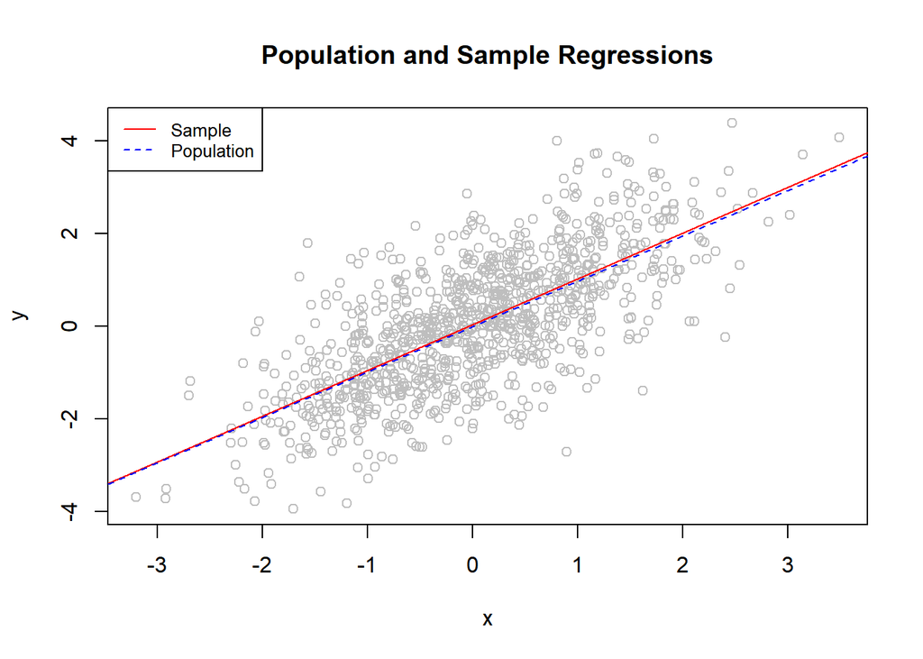

### Bootstrap Approach

The Bootstrap approach asks a question: what if we resample the data with replacement and estimate the coefficients, how extreme would it be?

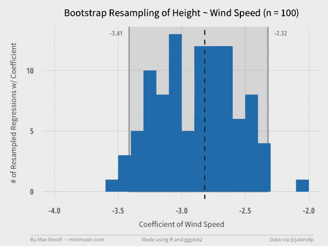

Here is a simple loop of 1000 trials, which resamples with replacement these 20 observations from our sample dataset, runs the regression model and saves the coefficients we get there. In the end, we would have 1000 pairs of coefficients.

```r
# Containers for the coefficients
sample_coef_intercept <- NULL
sample_coef_x1 <- NULL

for (i in 1:1000) {
  #Creating a resampled dataset from the sample data
  sample_d = sample.data[sample(1:nrow(sample.data), nrow(sample.data), replace = TRUE), ]

  #Running the regression on these data
  model_bootstrap <- lm(y ~ x, data = sample_d)

  #Saving the coefficients
  sample_coef_intercept <-
    c(sample_coef_intercept, model_bootstrap$coefficients[1])

  sample_coef_x1 <-
    c(sample_coef_x1, model_bootstrap$coefficients[2])
}

coefs <- rbind(sample_coef_intercept, sample_coef_x1)
```

We would take the average of these coefficients, and compare them with the other models we previously obtained:

Coefficients in different models

|  | population | sample | bootstrap |
| --- | --- | --- | --- |
| (Intercept) | 0.0377 | -0.0004 | 0.0272 |
| x | 0.9882 | 0.9794 | 0.9997 |

Precision of the confidence intervals

|  | 2.5 % | 97.5 % | 2.5 % | 97.5 % | 2.5 % | 97.5 % |
| --- | --- | --- | --- | --- | --- | --- |
|  | population | population | sample | sample | bootstrap | bootstrap |
| (Intercept) | -0.0255 | 0.1009 | -0.4252 | 0.4244 | -0.35 | 0.3765 |
| x | 0.9262 | 1.0503 | 0.5679 | 1.3909 | 0.5789 | 1.4969 |

We can see, that the precision is almost identical to the sample model’s, and even slightly tighter for the intercept.

### The graphical representation

First, the bootstrap representation:

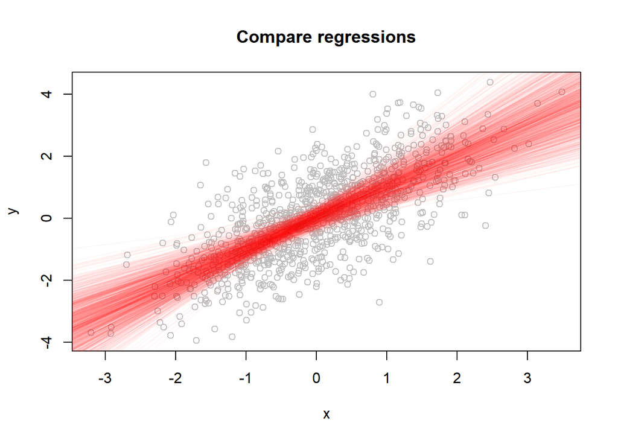

These are 1000 possible regression lines we have estimated. Now let’s add to the plot population, sample, and average bootstrap lines.

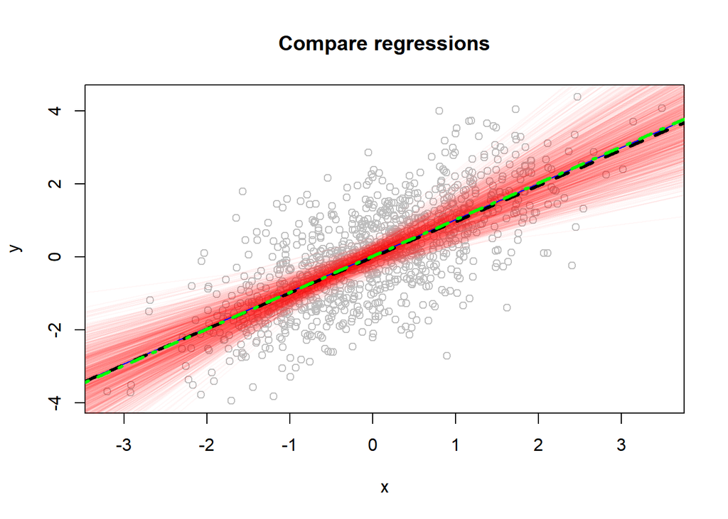

We can see that they essentially capture the data in the same way. Now let’s add the confidence intervals from the sample data:

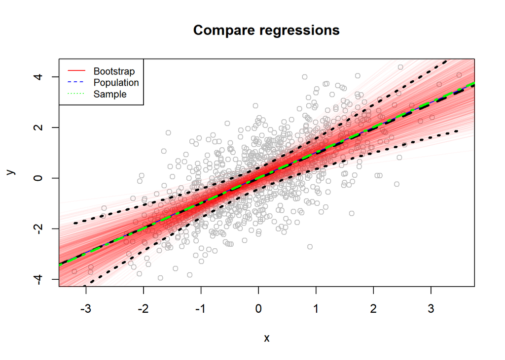

This completes our research: we may conclude, that the bootstrapping approach returns essentially the same results but in a statistically different fashion. We do not rely on assumptions but simulate the data using a brute force method. This could be especially useful when we have doubts about the distribution the data arrived from, or want to check the stability of the coefficients, particularly for small datasets.

### Iris

Going back to our `iris` dataset, and addresing multicollinearity issue:

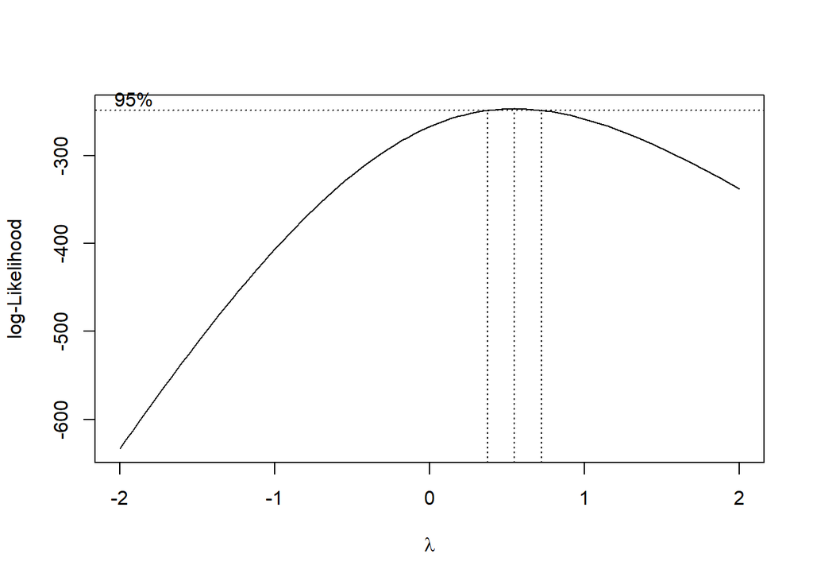

```r
fit1 <- lm(Petal.Width ~ Petal.Length + Sepal.Width + Sepal.Length, data = iris) # sqrt(vif(fit1)) >2 not good
fit2 <- lm(Petal.Width ~ Sepal.Width + Sepal.Length, data = iris)
sqrt(car::vif(fit2)) >2 # okay
gvlma(fit2)
boxcoxfit2 <- boxcox(fit2,plotit=T)
```

```r
lambda2 <- boxcoxfit2$x[which.max(boxcoxfit2$y)]
new_fit2 <- lm(((iris$Petal.Width^lambda2-1)/lambda2) ~  Sepal.Width + Sepal.Length, data = iris)
gvlma(new_fit2)
```

Let’s get back to `fit2` and use a a bootstrap approach:

```r
fit2.boot<-lm.boot(fit2, R=1000)
summary(fit2.boot)
```

```
## BOOTSTRAP OF LINEAR MODEL  (method = rows)
##
## Original Model Fit
## ------------------
## Call:
## lm(formula = Petal.Width ~ Sepal.Width + Sepal.Length, data = iris)
##
## Coefficients:
##  (Intercept)   Sepal.Width  Sepal.Length
##      -1.5635       -0.4787        0.7233
##
## Bootstrap SD's:
##  (Intercept)   Sepal.Width  Sepal.Length
##   0.33183730    0.06546793    0.03802357
```

Good for new prediction, but a more comprehensive alternative using function `Boot()` from the `car` package”:

```r
# can specify casewise or residual sampling with the method argument
fit3.boot <- Boot(fit2, f=coef, R=1000, method=c("case"))
summary(fit3.boot, high.moments=T)
```

```
##
## Number of bootstrap replications R = 1000
##              original    bootBias   bootSE  bootMed bootSkew bootKurtosis
## (Intercept)  -1.56349 -0.00993770 0.346671 -1.54587 -0.15458      0.29403
## Sepal.Width  -0.47872  0.00225778 0.067385 -0.47788  0.16465      0.36530
## Sepal.Length  0.72329  0.00063463 0.038462  0.72115  0.12684      0.31195
```

Fit 2 is not too bad overall !!!

## Cross Validation

**Two types**

Two types of cross-validation can be distinguished: exhaustive and non-exhaustive cross-validation.

- Exhaustive cross-validation

Exhaustive cross-validation methods are cross-validation methods which learn and test on all possible ways to divide the original sample into a training and a validation set.

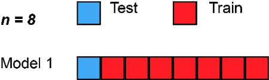

Non-exhaustive cross validation methods do not compute all ways of splitting the original sample. These methods are approximations of leave-p-out cross-validation.

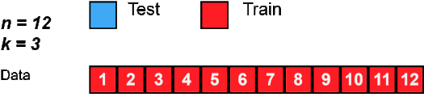

You can do K-Fold cross-validation using the `cv.lm( )` function in the DAAG package.

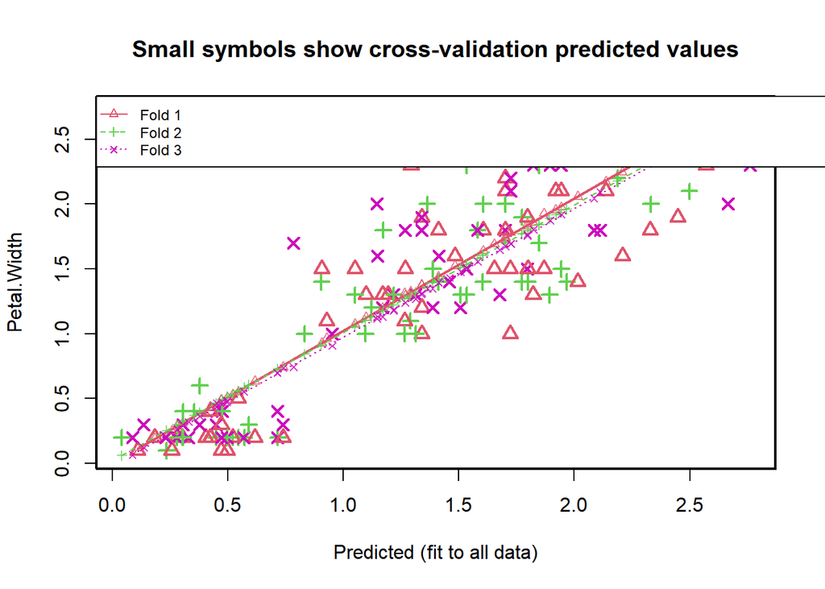

```
##
## fold 1
## Observations in test set: 50
##                      3           4          8         10         13          14
## Predicted    0.3040719  0.27961484  0.4253152  0.4966024  0.4721454  0.11049937
## cvpred       0.3097450  0.28805173  0.4264995  0.5081553  0.4864620  0.11962273
## Petal.Width  0.2000000  0.20000000  0.2000000  0.1000000  0.1000000  0.10000000
## CV residual -0.1097450 -0.08805173 -0.2264995 -0.4081553 -0.3864620 -0.01962273
##                      24         26          27         31         34         36
## Predicted    0.54551657  0.6168038  0.42531524  0.4242732  0.4039842  0.5210595
## cvpred       0.55154187  0.6331977  0.42649947  0.4347874  0.3799423  0.5298486
## Petal.Width  0.50000000  0.2000000  0.40000000  0.2000000  0.2000000  0.2000000
## CV residual -0.05154187 -0.4331977 -0.02649947 -0.2347874 -0.1799423 -0.3298486
##                     37         38          39         46         59        62
## Predicted    0.7390891  0.2572418 0.182828571  0.4721454  1.8219431 1.2677666
## cvpred       0.7416642  0.2497825 0.192990578  0.4864620  1.8587578 1.2935083
## Petal.Width  0.2000000  0.1000000 0.200000000  0.3000000  1.3000000 1.5000000
## CV residual -0.5416642 -0.1497825 0.007009422 -0.1864620 -0.5587578 0.2064917
##                     63        65        67         68         69         77
## Predicted    1.7230728 1.0986511 1.0507790  1.3390538  1.8677312  2.0144736
## cvpred       1.7802726 1.1250793 1.0734048  1.3751642  1.9270083  2.0571681
## Petal.Width  1.0000000 1.3000000 1.5000000  1.0000000  1.5000000  1.4000000
## CV residual -0.7802726 0.1749207 0.4265952 -0.3751642 -0.4270083 -0.6571681
##                     81         83         84        85         87         95
## Predicted    1.2656826  1.3390538 1.48371216 0.9061206  1.7985280 1.19439536
## cvpred       1.3100843  1.3751642 1.52189985 0.9266691  1.8287766 1.22842845
## Petal.Width  1.1000000  1.2000000 1.60000000 1.5000000  1.5000000 1.30000000
## CV residual -0.2100843 -0.1751642 0.07810015 0.5733309 -0.3287766 0.07157155
##                    97        99       102         103       104       105
## Predicted   1.1709803 0.9284936 1.3390538  2.13571697 1.6049555 1.7017418
## cvpred      1.1984472 0.9649383 1.3751642  2.17392255 1.6386543 1.7337154
## Petal.Width 1.3000000 1.1000000 1.9000000  2.10000000 1.8000000 2.2000000
## CV residual 0.1015528 0.1350617 0.5248358 -0.07392255 0.1613457 0.4662846
##                    108      113      115        120       124       125
## Predicted    2.3282475 1.918729 1.291182  1.7230728 1.7006998 1.7027838
## cvpred       2.3723328 1.953819 1.323490  1.7802726 1.7420034 1.7254275
## Petal.Width  1.8000000 2.100000 2.400000  1.5000000 1.8000000 2.1000000
## CV residual -0.5723328 0.146181 1.076510 -0.2802726 0.0579966 0.3745725
##                  128        130        131        134        136       140
## Predicted   1.412425  2.2080462  2.4484488  1.6528276  2.5696922 1.9431864
```

[output cut: 99 more lines]

```
## Predicted   1.7251568 1.7251568 1.365595 1.5815404 1.3400958 1.943186 1.3390538
## cvpred      1.6929854 1.6929854 1.349939 1.5576384 1.3133439 1.919401 1.3039859
## Petal.Width 2.1000000 2.2000000 2.400000 1.8000000 1.8000000 2.300000 1.9000000
## CV residual 0.4070146 0.5070146 1.050061 0.2423616 0.4866561 0.380599 0.5960141
##                   144       150
## Predicted   1.8229851 1.2677666
## cvpred      1.8019328 1.2409914
## Petal.Width 2.3000000 1.8000000
## CV residual 0.4980672 0.5590086
##
## Sum of squares = 8.36    Mean square = 0.17    n = 50
##
## Overall (Sum over all 50 folds)
##        ms
## 0.1513302
```

```r
# K-fold cross-validation
cv.lm(iris, fit2, m=3) # 3 fold cross-validation
```

Sum the Mean Square Error (MSE) for each fold, divide by the number of observations, and take the square root to get the cross-validated standard error of estimate.

You can assess R2 shrinkage via K-fold cross-validation. Using the `crossval()` function from the `bootstrap` package, do the following:

```r
# Assessing R2 shrinkage using 10-Fold Cross-Validation
# define functions
theta.fit <- function(x,y){lsfit(x,y)}
theta.predict <- function(fit,x){cbind(1,x)%*%fit$coef}
# matrix of predictors
X <- as.matrix(iris[c("Sepal.Width","Sepal.Length")])
# vector of predicted values
y <- as.matrix(iris[c("Petal.Width")])
results <- crossval(X,y,theta.fit,theta.predict,ngroup=3)
cor(y, fit2$fitted.values)**2 # raw R2
```

```
##                 [,1]
## Petal.Width 0.742928
```

```r
cor(y,results$cv.fit)**2 # cross-validated R2
```

```
##                  [,1]
## Petal.Width 0.7401434
```

## Comparing Models

Let’s change of data set to make it a bit more simple from now: salaries and other information of 62 professors in Cohen et. al. (2003, pp. 81-82). Check `?prof.salary`.

```r
library("MBESS")
data(prof.salary)
```

We now build a serie of simple regression models

```r
fit.prof1 <- lm(salary~pub, data=prof.salary)
fit.prof2  <- lm(salary~citation, data=prof.salary)
fit.prof3 <- lm(salary~pub+citation, data=prof.salary)
fit.prof4  <- lm(salary~citation+pub, data=prof.salary)
```

Check [here](https://bcdudek.net/regression1/implementation-of-standard-multiple-regression-analyses-linear-modeling-with-multiple-ivs.html#diagnostic-and-added-variable-plots-for-the-full-two-iv-model) for the regression diagnostics and influence analysis.

We can pass two linear models to `anova` and ask it to compare them. We consider beginning wth fit.prof1 (only `pubs` was an independent variable in that simple regression), and compare fit.prof3 (which also included `cits` as an independent variable) to test the increment in the R-squared produced by the inclusion of `cits`. The F value matches the Type III SS F test for `cits` and is the square of the *t* value that tested the regression coefficient of `cits`.

```r
# compare model 3 to model 1 - stepping approach, evaluating a new variable (cits)
anova(fit.prof1,fit.prof3)# note this is anova, not Anova
```

```
## Analysis of Variance Table
##
## Model 1: salary ~ pub
## Model 2: salary ~ pub + citation
##   Res.Df        RSS Df Sum of Sq      F    Pr(>F)
## 1     60 4274424497
## 2     59 3335822387  1 938602110 16.601 0.0001396 ***
## ---
## Signif. codes:  0 '***' 0.001 '**' 0.01 '*' 0.05 '.' 0.1 ' ' 1
```

The next illustration compares the full model to the simple regression that only contained cits (fit2). The test is therefore the test of an hypothesis that increment in SS accounted for by pubs is zero. And this F also matches the F test of the Type III SS seen above.

```r
# compare model 3 to model 2 - stepping approach, evaluating a new variable (pubs)
anova(fit.prof2,fit.prof3)# note this is anova, not Anova
```

```
## Analysis of Variance Table
##
## Model 1: salary ~ citation
## Model 2: salary ~ pub + citation
##   Res.Df        RSS Df Sum of Sq      F   Pr(>F)
## 1     60 4009743405
## 2     59 3335822387  1 673921018 11.919 0.001034 **
## ---
## Signif. codes:  0 '***' 0.001 '**' 0.01 '*' 0.05 '.' 0.1 ' ' 1
```

## Variable Selection

An information criterion balances the fitness of a model with the number of predictors employed. Hence, it determines objectively the best model as the one that minimizes the information criterion. Two common criteria are the **Bayesian Information Criterion (BIC)** and the **Akaike Information Criterion (AIC)**.

$AIC(model)=-2*logLik(model) + npar(model) * 2$

$BIC(model)=-2*logLik(model) + npar(model) * log(n)$

where $Lik(model)$ is the likelihood of the model (how well the model fits the data) and $npar(model)$ is the number of parameters of the model, $k+2$ in the case of a multiple linear regression model with $k$ predictors.The AIC replaces $log(n)$ by $2$, so it penalizes less complex models.This is one of the reasons why BIC is preferred by some practitioners for model comparison. Also, because is consistent in selecting the true model: if enough data is provided, the BIC is guaranteed to select the data-generating model among a list of candidate models.

Both are based on a **balance between the model fitness and its complexity**.Both BIC and AIC can be computed in `R` through the functions `BIC` and `AIC`. They take a model as the input. The lower the better with a rule of thumb = 2.

```r
BIC(fit.prof1); BIC(fit.prof2);BIC(fit.prof3)
```

```
## [1] 1307.354
```

```
## [1] 1303.391
```

```
## [1] 1296.11
```

```r
AIC(fit.prof1); AIC(fit.prof2);AIC(fit.prof3)
```

```
## [1] 1300.973
```

```
## [1] 1297.01
```

```
## [1] 1287.601
```

However, selecting a subset of predictor variables from a larger set (e.g., stepwise selection) remains a controversial topic. You can perform stepwise selection (forward, backward, both) using the `stepAIC()` and `stepBIC()` function from the `MASS` package. `stepAIC()` performs stepwise model selection by exact AIC.

```r
# Stepwise Selection based on AIC
fit.prof5  <- lm(salary~citation+pub+time, data=prof.salary)
step1 <- stepAIC(fit.prof5, direction="both")
```

```
## Start:  AIC=1102.26
## salary ~ citation + pub + time
##
##            Df Sum of Sq        RSS    AIC
## - pub       1  59458298 2926312249 1101.5
## <none>                  2866853951 1102.3
## - time      1 468968436 3335822387 1109.7
## - citation  1 634124345 3500978295 1112.7
##
## Step:  AIC=1101.53
## salary ~ citation + time
##
##            Df  Sum of Sq        RSS    AIC
## <none>                   2926312249 1101.5
## + pub       1   59458298 2866853951 1102.3
## - citation  1  696719756 3623032005 1112.8
## - time      1 1083431156 4009743405 1119.1
```

```r
step1$anova # display results
```

```
## Stepwise Model Path
## Analysis of Deviance Table
##
## Initial Model:
## salary ~ citation + pub + time
##
## Final Model:
## salary ~ citation + time
##
##
##    Step Df Deviance Resid. Df Resid. Dev      AIC
## 1                          58 2866853951 1102.259
## 2 - pub  1 59458298        59 2926312249 1101.532
```

```r
#Stepwise Selection with BIC
n<-dim(prof.salary)[1]
step2 <- stepAIC(fit.prof5, k=log(n), direction="both")
```

```
## Start:  AIC=1110.77
## salary ~ citation + pub + time
##
##            Df Sum of Sq        RSS    AIC
## - pub       1  59458298 2926312249 1107.9
## <none>                  2866853951 1110.8
## - time      1 468968436 3335822387 1116.0
## - citation  1 634124345 3500978295 1119.0
##
## Step:  AIC=1107.91
## salary ~ citation + time
##
##            Df  Sum of Sq        RSS    AIC
## <none>                   2926312249 1107.9
## + pub       1   59458298 2866853951 1110.8
## - citation  1  696719756 3623032005 1117.0
## - time      1 1083431156 4009743405 1123.3
```

```r
step2$anova # display results
```

```
## Stepwise Model Path
## Analysis of Deviance Table
##
## Initial Model:
## salary ~ citation + pub + time
##
## Final Model:
## salary ~ citation + time
##
##
##    Step Df Deviance Resid. Df Resid. Dev      AIC
## 1                          58 2866853951 1110.768
## 2 - pub  1 59458298        59 2926312249 1107.914
```

When applying `stepAIC` for BIC/AIC, different final models might be selected depending on the choice of direction. This is the interpretation:

- `“backward”`: starts from the full model, removes predictors sequentially.
- `“forward”`: starts from the simplest model, adds predictors sequentially.
- `“both”` (default): combination of the above.

The advice is to try several of these methods and retain the one with minimum BIC/AIC. Set trace = 0 to omit lengthy outputs of information of the search procedure.

Alternatively, you can perform all-subsets regression using the `leaps()` function from the `leaps` package. In the following code `nbest` indicates the number of subsets of each size to report. Here, the ten best models will be reported for each subset size (1 predictor, 2 predictors, etc.).

```r
# All Subsets Regression
leaps<-regsubsets(salary~citation+pub+time, data=prof.salary,nbest=10)
# view results
summary(leaps)
```

```
## Subset selection object
## Call: regsubsets.formula(salary ~ citation + pub + time, data = prof.salary,
##     nbest = 10)
## 3 Variables  (and intercept)
##          Forced in Forced out
## citation     FALSE      FALSE
## pub          FALSE      FALSE
## time         FALSE      FALSE
## 10 subsets of each size up to 3
## Selection Algorithm: exhaustive
##          citation pub time
## 1  ( 1 ) " "      " " "*"
## 1  ( 2 ) "*"      " " " "
## 1  ( 3 ) " "      "*" " "
## 2  ( 1 ) "*"      " " "*"
## 2  ( 2 ) "*"      "*" " "
## 2  ( 3 ) " "      "*" "*"
## 3  ( 1 ) "*"      "*" "*"
```

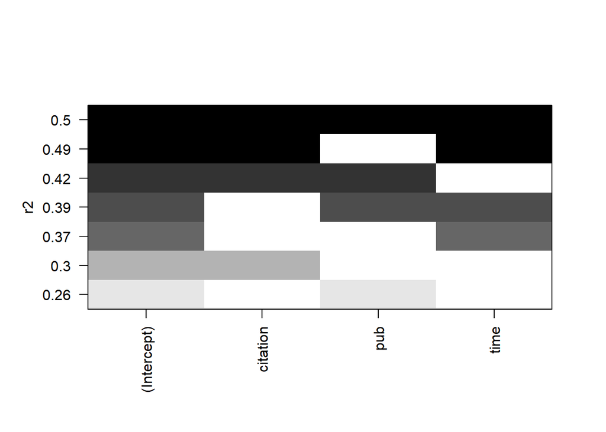

```r
# plot a table of models showing variables in each model.
# models are ordered by the selection statistic.
plot(leaps,scale="r2")
```

```r
# plot statistic by subset size
# subsets(leaps, statistic="rsq")
```

Other options for `plot()` are bic, Cp, and adjr2. Other options for plotting with `subset()` are bic, cp, adjr2, and rss.

## Model assesment

It turns out that:

```r
fit.prof6  <- lm(salary~citation+time, data=prof.salary)
# gvlma(fit.prof6)
summary(fit.prof6)
```

```
##
## Call:
## lm(formula = salary ~ citation + time, data = prof.salary)
##
## Residuals:
##      Min       1Q   Median       3Q      Max
## -14809.6  -4364.9   -479.6   3960.7  22449.2
##
## Coefficients:
##             Estimate Std. Error t value Pr(>|t|)
## (Intercept) 39073.67    2396.47  16.305  < 2e-16 ***
## citation      212.11      56.59   3.748 0.000408 ***
## time         1061.76     227.18   4.674 1.76e-05 ***
## ---
## Signif. codes:  0 '***' 0.001 '**' 0.01 '*' 0.05 '.' 0.1 ' ' 1
##
## Residual standard error: 7043 on 59 degrees of freedom
## Multiple R-squared:  0.4908, Adjusted R-squared:  0.4735
## F-statistic: 28.43 on 2 and 59 DF,  p-value: 2.258e-09
```

The first step in interpreting the multiple regression analysis is to examine the *F*-statistic and the associated *p*-value, at the bottom of the model summary.

In our example, it can be seen that p-value of the F-statistic is `p-value: 2.258e-09`, which is highly significant. This means that, at least, one of the predictor variables is significantly related to the outcome variable.

To see which predictor variables are significant, you can examine the coefficients table, which shows the estimate of regression beta coefficients and the associated t-statistic p-values:

```r
summary(fit.prof6)$coefficient
```

```
##               Estimate Std. Error   t value     Pr(>|t|)
## (Intercept) 39073.6747 2396.47360 16.304655 1.593845e-23
## citation      212.1116   56.59392  3.747958 4.078031e-04
## time         1061.7642  227.17563  4.673759 1.761335e-05
```

For a given predictor, the *t*-statistic evaluates whether or not there is significant association between this predictor and the outcome variable, that is whether the beta coefficient of the predictor is significantly different from zero.

It can be seen that, changes in `citation` and `time` are both significantly associated to changes in `salary`. For a given predictor variable, the coefficient ($\beta$) can be interpreted as the average effect on $y$ of a one unit increase in predictor, holding all other predictors fixed.

For example, for a fixed values of `citation` the increase of one unit of `time` increase salary of `1061` unit on average (vs. `1379` unit in our example using a simple linear regression). If a predictor was not significant in our multiple regression model, it means that its change will not significantly affect `salary`. Therefore, it is possible to remove it from the model.

As we saw earlier, the confidence interval of the model coefficient can be extracted as follow:

```r
confint(fit.prof6)
```

```
##                   2.5 %     97.5 %
## (Intercept) 34278.34213 43869.0073
## citation       98.86747   325.3558
## time          607.18682  1516.3416
```

### Accuracy

As we have seen in simple linear regression, the overall quality of the model can be assessed by examining the R-squared ($R^2$) and Residual Standard Error (RSE).

1. **The R-squared ($R^2$)**

In multiple linear regression, the $R$ represents the correlation coefficient between the observed values of the outcome variable ($y$) and the fitted (i.e., predicted) values of $y$. For this reason, the value of $R$ will always be positive and will range from zero to one.

$R^2$ represents the proportion of variance, in the outcome variable y, that may be predicted by knowing the value of the $x$ variables. An $R^2$ value close to 1 indicates that the model explains a large portion of the variance in the outcome variable.

A problem with the $R^2$, is that, it will always increase when more variables are added to the model, even if those variables are only weakly associated with the response (James et al. 2014). A solution is to adjust the $R^2$ by taking into account the number of predictor variables.

The adjustment in the “Adjusted R-Squared” value in the summary output is a correction for the number of $x$ variables included in the prediction model.

2. **The Residual Standard Error (RSE).**

As mentioned earlier, the RSE estimate gives a measure of error of prediction. The lower the RSE, the more accurate the model (on the data in hand).

The error rate can be estimated by dividing the RSE by the mean outcome variable:

```r
sigma(fit.prof6)/mean(prof.salary$salary)
```

```
## [1] 0.128478
```

### Model customization

To compute multiple regression using all of the predictors in the data set, simply type this:

```r
model.full <- lm(salary ~., data = prof.salary)
```

```r
model.partial1 <- lm(salary ~. -sex, data = prof.salary) # salary~".", the "." means all of the variables in the dataset
```

Alternatively, you can use the update function:

```r
model.partial2 <-  update(model.full,  ~. -sex)
```